# SIAHL Ringers are Spoiling the Lower Leagues

### **An open letter to Sharks Ice Adult Hockey League Management**

The Sharks Ice Adult Hockey League is unquestionably an impressive organization with nearly 2000 active adult players and well over 100 teams. Games are well run, and players at all levels can find a league that suits their level of intensity and ability. The league is also impressively open with the game statistics which make it fun to track individual and team statistics within and across seasons. A fact we’ll take advantage of for this analysis.

As a long time Sharks Ice player, I’ve watch the league (and it’s predecessors) grow over the past 30+ years. As the level of play improves, age catches up with my own skills and I’ve had to drop levels over time in order to remain competitive. Unfortunately, its impossible to miss the fact that the lower skilled divisions have a severe and increasing problem with ringers, that is, players whose skill and stamina far exceed the level they are playing in. As in all recreational sports, there are some athletes that prefer to compete below their ability. Reasons can vary, and in some cases, the decision may be justified, but its important to recognize the impact this has on the lower leagues and individual players in them who are wanting to develop their own skills and engage in fair competition.

Why does this matter? Because most of us who enjoy sports, hold the integrity of the match in high regard, and expect the rules, referees and organizers to facilitate a fair match to the best extent possible. It’s important for the health of the league as well, since fair play makes for a better experience for newcomers, ensuring a healthy and growing increase in players.

The bottom line for the league management is clear. By allowing ringers to upset the natural competitive balance within a division, the league risks choking off an important source of future revenue by discouraging those newcomers.

### Is the ringer effect real?

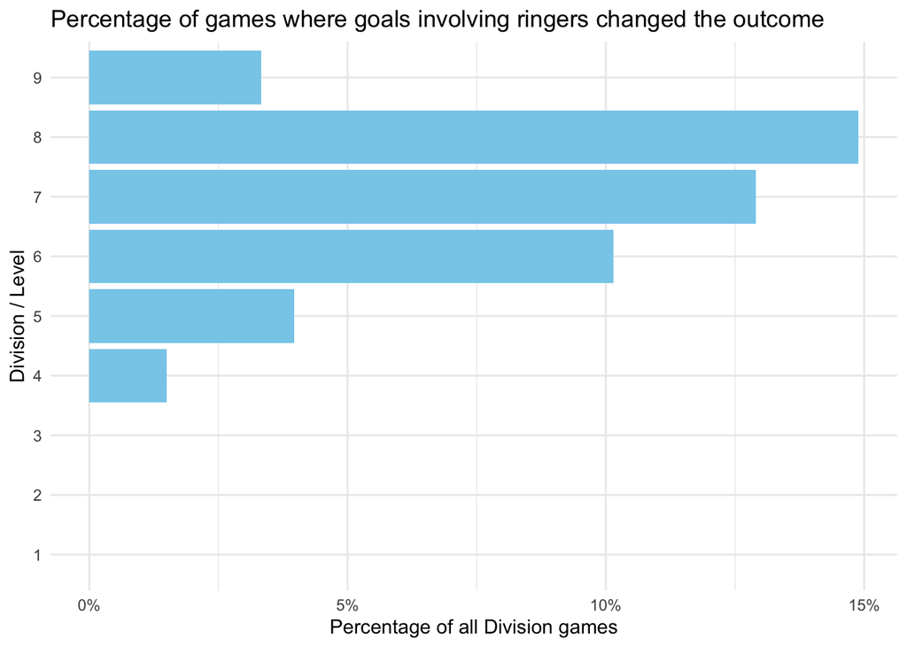

The remainder of this article explains the methodology behind this conclusion and shows an example of one of the teams whose standings were radically improved due to the ringers on their roster. We also suggest a straight-forward remedy to help curtail the unsportsmanlike practice of enlisting ringers to influence team’s game outcomes and league rankings.

Let’s start with some simple facts about about the league. This data represents the most recently completed season, `Winter 2023`.

Winter 2023 Season

[output not shown]

Let’s break that down a bit further by looking at Division/Levels. For clarity, a Division/Level looks only at the division number, for example 7A and 7B designate 2 separate divisions, but the same Division/Level. There are 9 Division/Levels overall, and we count a ringer as any player who has played a game at least 3 Division/Levels below their highest level. The Ringer/Game Count sums the number of games each player has played as a ringer.

| DivLevel | Player Count | Ringer Count | Ringer/Game Count |
| --- | --- | --- | --- |
| 1 | 88 | 0 | 0 |
| 2 | 62 | 0 | 0 |
| 3 | 249 | 0 | 0 |
| 4 | 417 | 3 | 6 |
| 5 | 431 | 7 | 22 |
| 6 | 639 | 16 | 99 |
| 7 | 835 | 42 | 201 |
| 8 | 503 | 43 | 191 |
| 9 | 110 | 6 | 17 |

There’s a weak correlation (r = -0.028) between the Ringer/Game Count and the team rankings at the end of the season, which would initially imply that the ringers don’t have a major impact on the season outcomes, but a more thorough look tells a different story.

One way to attempt to quantify a ringer impact at the game level is to look at scoring that involves ringers. That is, if a ringer scores or assists a goal in a game, we can remove that point from the score and compare the adjusted score to the actual final score to see if the outcome is affected. To illustrate, let’s look at [this Division 6B game](https://stats.sharksice.timetoscore.com/oss-scoresheet?game_id=374162&mode=display) between `Seal Team Sticks` and `Ice Breakers` . The final score was 8-2 in favor of the `Seal Team Sticks` giving them a decided 2 pts[^3] towards their #2 rank for the final season.

[figure not shown]

Seal Team Sticks vs Ice Breakers / Game 374162

Now let’s take a look at the scoring for the game: It’s arranged here with goals, primary and secondary assists on the left for the visiting team, and on the right for the home team. Goals that involved a player identified as a ringer are highlighted in yellow, and have an asterisk (*) in the `adj` column.

| Period | Time | A Goal | A Asst1 | A Asst2 | adj | H Goal | H Asst1 | H Asst2 |
| --- | --- | --- | --- | --- | --- | --- | --- | --- |
| 1 | 19:23 | 78 |  |  |  | — | — | — |
| 1 | 12:38 | — | — | — |  | 9 | 96 |  |
| 1 | 6:22 | 69 | 56 |  | * | — | — | — |
| 1 | 3:37 | — | — | — |  | 12 |  |  |
| 1 | 1:01 | 83 | 17 |  |  | — | — | — |
| 3 | 14:41 | 56 | 42 |  | * | — | — | — |
| 3 | 10:59 | 8 | 71 |  | * | — | — | — |
| 3 | 10:22 | 56 | 69 | 8 | * | — | — | — |
| 3 | 4:49 | 69 | 56 |  | * | — | — | — |
| 3 | 3:13 | 8 |  |  | * | — | — | — |

Only `Seal Team Sticks` has ringers in this match, and they have three of them (jersies #8, #42, and #69). Between them they have 4 goals and helpers on 2 more. Quite an impact! Those goals changed what would otherwise have been a tie into a 6 goal rout.

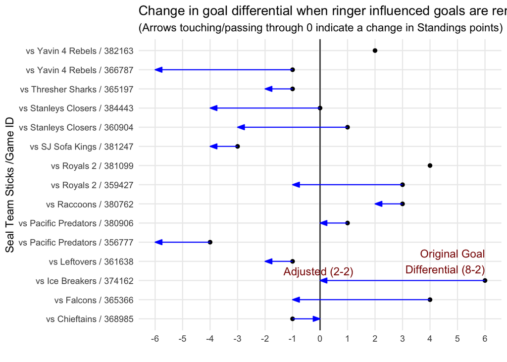

More comprehensively, we can see how all the teams standings in this division would have changed, if the adjusted score had been the actual score. This has a material impact on teams that miss the playoffs because they were pushed lower in the standings by teams that inflated their league standings through the use of ringers.

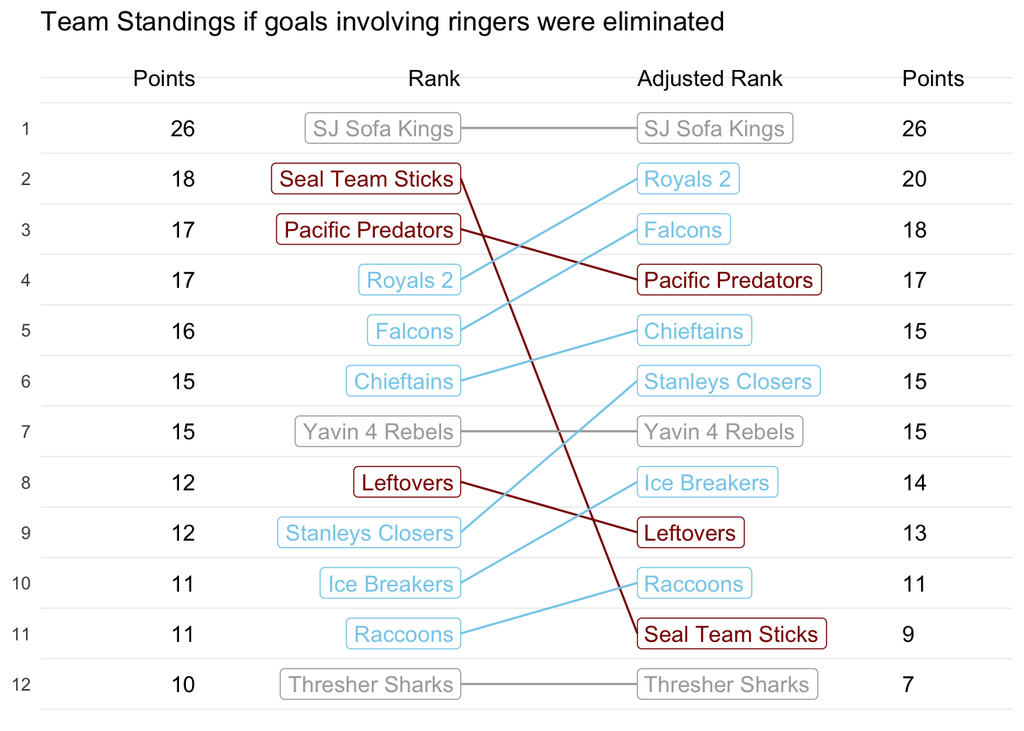

In this case `Seal Team Sticks` season standings would have plummeted if they had not had the scoring help from their ringers who provided 78% of the team’s scoring. More generally, the plot shows how teams may be getting unfairly bumped out of the playoffs, due to the inflated rankings of teams that rely on ringers for their scoring.

To be sure, we can’t assume the adjusted scores would reasonably forecast alternative outcomes using this method, but instead propose the adjustment as a proxy for measuring one aspect of how ringers affect games. There are certainly other effects at play that would be harder to measure. For example a defenseman playing in a league they are overqualified for is likely to shut down scoring for more novice players, but their individual impact wouldn’t be directly observable on the score sheet.

### How to address the problem

The league already has a policy against players playing on teams that span more than 2 division levels. Unfortunately, this rule hasn’t been enforced, presumably because it’s difficult to identify the ringers in time to prevent them from playing.

This problem can be easily addressed using an app that scans past and current game rosters to alert captains to potential violations. A proof-of-concept application has been developed for this purpose.

[figure not shown]

Mobile friendly Shiny app

*NOTE*: This is app is a preliminary proof-of-concept, and should only be used to get an idea for what is possible.

It is best viewed on an iPhone, but a simulation with example game links is available at https://dsdaveh.github.io/siahl-ringers/. To view the app directly from a mobile device click [here](https://dsdaveh.shinyapps.io/siahl_ringers/)

To use it, you can enter a Game ID via one of three methods:

1. Enter the GameID directly.  
   These are visible from team pages (eg [Choking Hazards-Spring 2023](https://stats.sharksice.timetoscore.com/display-schedule?team=3329&season=59&league=1&stat_class=1))
2. Use the example game dropdown to view one of the games with ringer effects detected.
3. Use the team dropdown to select a team.
   1. The dropdown options will repopulate with games specific to that team.
   2. Select a game from the new dropdown options
- `Score` is the actual games score
- `Adj* Score` is the score if all goals involving ringers were removed
- `Ringers` are a list of players who also play on teams in higher skilled (lower numbered) divisions more than 2 from division the current game is being played in
- Yellow lines in the score line indicate goals that would be removed for the “adjustment”

Putting such a policy in place, would be a great first step to cleansing the league from the affects of players who corrupt the fairness principles inherent to sports, and would encourage novice players who endeavour to learn the great sport of hockey as adults.

There’s more that could be done to insure a more even level of play across each division, but the initial suggestion outlined here would be an uncontroversial and relatively easy process to begin with. By instituting it, the Sharks Ice management would affirm their commitment to fair play, and would safeguard a path to both player and franchise fans growth over the future.

Thank you for reading! Please send questions or feedback to

*insights@scalingdatascience.com*

## Footnotes

[^1]: Division numbers go up as the level of play goes down. I.e. Division 1 is the most skilled.
[^2]: For example, a player that is playing far below their ability, but not also rostered on teams at a more appropriate level would not be identified as a ringer.
[^3]: A team earns 2 points for a win, 1 point for a regulation tie, and no points for a loss.
[^4]: Adjusted score is the score if all goals that involved ringers were removed from the actual final score.